# DATA2902 Group Project

## Appendix

We want to remove Density measurement, since this is generally harder to calculate.

```r
full_model = lm(Pct.BF ~ . - Density, data = bodyfat)  # Full model
round(summary(full_model)$coef, 3)
```

```
##             Estimate Std. Error t value Pr(>|t|)
## (Intercept)    1.685     23.374   0.072    0.943
## Age            0.072      0.032   2.234    0.026
## Weight        -0.039      0.148  -0.263    0.793
## Height        -0.097      0.075  -1.291    0.198
## Neck          -0.387      0.235  -1.647    0.101
## Chest         -0.119      0.108  -1.101    0.272
## Abdomen        0.905      0.091   9.897    0.000
## Hip           -0.159      0.146  -1.089    0.277
## Thigh          0.173      0.147   1.178    0.240
## Knee          -0.046      0.246  -0.186    0.852
## Ankle          0.185      0.220   0.842    0.401
## Bicep          0.180      0.170   1.054    0.293
## Forearm        0.276      0.207   1.334    0.183
## Wrist         -1.802      0.533  -3.380    0.001
```

#### Backward variable selection

Backward search using AIC

```r
step.back.aic = step(full_model,
                     direction = "backward",
                     trace = FALSE)
s = round(summary(step.back.aic)$coef,3)
s
```

```
##             Estimate Std. Error t value Pr(>|t|)
## (Intercept)    5.040      8.359   0.603    0.547
## Age            0.073      0.030   2.396    0.017
## Height        -0.106      0.050  -2.125    0.035
## Neck          -0.451      0.218  -2.073    0.039
## Abdomen        0.823      0.069  11.958    0.000
## Hip           -0.195      0.130  -1.501    0.135
## Thigh          0.224      0.129   1.735    0.084
## Forearm        0.296      0.192   1.542    0.124
## Wrist         -1.731      0.494  -3.506    0.001
```

```r
#pulling out the variables which were kept
# model_vars = as.data.frame(s[, 0])[2:9, 1]
model_vars = c("Age", "Height", "Neck", "Abdomen", "Hip", "Thigh", "Forearm", "Wrist")
```

#### Backward with assumptions

```r
step_back_true = lm(Pct.BF ~ Neck + Abdomen + Hip + Thigh + Forearm + Wrist, data = bodyfat)
summary(step_back_true)
```

```
##
## Call:
## lm(formula = Pct.BF ~ Neck + Abdomen + Hip + Thigh + Forearm +
##     Wrist, data = bodyfat)
##
## Residuals:
##     Min      1Q  Median      3Q     Max
## -9.7366 -3.1103 -0.1883  3.1152 11.4653
##
## Coefficients:
##             Estimate Std. Error t value Pr(>|t|)
## (Intercept) -0.44394    6.56760  -0.068 0.946163
## Neck        -0.48636    0.22186  -2.192 0.029315 *
## Abdomen      0.96205    0.05691  16.904  < 2e-16 ***
## Hip         -0.36347    0.12293  -2.957 0.003416 **
## Thigh        0.12843    0.12290   1.045 0.297062
## Forearm      0.21762    0.19358   1.124 0.262023
## Wrist       -1.56314    0.46406  -3.368 0.000879 ***
## ---
## Signif. codes:  0 '***' 0.001 '**' 0.01 '*' 0.05 '.' 0.1 ' ' 1
##
## Residual standard error: 4.332 on 243 degrees of freedom
## Multiple R-squared:  0.7337, Adjusted R-squared:  0.7271
## F-statistic: 111.6 on 6 and 243 DF,  p-value: < 2.2e-16
```

#### Foward variable selection using AIC

```r
null_model = lm(Pct.BF ~ 1, data = bodyfat)
step.forward.aic = step(null_model,
                        scope = list(lower = null_model, upper = full_model),
                        direction = "forward",
                        trace = FALSE)
round(summary(step.forward.aic)$coef,3)
```

```
##             Estimate Std. Error t value Pr(>|t|)
## (Intercept)  -32.574      8.363  -3.895    0.000
## Waist          2.246      0.177  12.658    0.000
## Weight        -0.236      0.076  -3.086    0.002
## Wrist         -1.764      0.486  -3.627    0.000
## Bicep          0.243      0.156   1.558    0.121
## Age            0.062      0.031   2.012    0.045
## Thigh          0.178      0.121   1.474    0.142
```

```r
back = step(step_back_true,
                        scope = list(lower = null_model, upper = full_model),
                        direction = "forward",
                        trace = FALSE)
round(summary(back)$coef,3)
```

```
##             Estimate Std. Error t value Pr(>|t|)
## (Intercept)    5.040      8.359   0.603    0.547
## Neck          -0.451      0.218  -2.073    0.039
## Abdomen        0.823      0.069  11.958    0.000
## Hip           -0.195      0.130  -1.501    0.135
## Thigh          0.224      0.129   1.735    0.084
## Forearm        0.296      0.192   1.542    0.124
## Wrist         -1.731      0.494  -3.506    0.001
## Age            0.073      0.030   2.396    0.017
## Height        -0.106      0.050  -2.125    0.035
```

### Exhaustive searches

```r
exh = regsubsets(Pct.BF ~ . -Density, data = bodyfat, nvmax = 15)
summary(exh)$outmat
```

[output not shown]

## Model stability model selection

```r
model_stab = lm(Pct.BF ~ Weight + Abdomen + Wrist, data = bodyfat)
summary(model_stab)
```

```
##
## Call:
## lm(formula = Pct.BF ~ Weight + Abdomen + Wrist, data = bodyfat)
##
## Residuals:
##     Min      1Q  Median      3Q     Max
## -9.7562 -3.1974 -0.4657  3.2926  9.9233
##
## Coefficients:
##              Estimate Std. Error t value Pr(>|t|)
## (Intercept) -27.89295    6.72673  -4.147 4.65e-05 ***
## Weight       -0.20675    0.05328  -3.880 0.000134 ***
## Abdomen       0.96030    0.05522  17.389  < 2e-16 ***
## Wrist        -1.37195    0.43562  -3.149 0.001838 **
## ---
## Signif. codes:  0 '***' 0.001 '**' 0.01 '*' 0.05 '.' 0.1 ' ' 1
##
## Residual standard error: 4.308 on 246 degrees of freedom
## Multiple R-squared:  0.7335, Adjusted R-squared:  0.7303
## F-statistic: 225.7 on 3 and 246 DF,  p-value: < 2.2e-16
```

# 10 fold cross validation results

```r
library(klaR)
cv_all = train(
  Pct.BF ~ . - Density,
  bodyfat,
  method = "lm",
  trControl = trainControl(
    method = "cv", number = 10,
    verboseIter = FALSE
  )
)


cv_forward = train(
  Pct.BF ~ Waist + Weight + Wrist + Bicep + Age + Thigh,
  bodyfat,
  method = "lm",
  trControl = trainControl(
    method = "cv", number = 10,
    verboseIter = FALSE
  )
)

cv_backward = train(
  Pct.BF ~ Neck + Abdomen + Hip + Thigh + Forearm + Wrist,
  bodyfat,
  method = "lm",
  trControl = trainControl(
    method = "cv", number = 10,
    verboseIter = FALSE
  )
)

cv_stable = train(
  Pct.BF ~ Weight + Abdomen + Wrist,
  bodyfat,
  method = "lm",
  trControl = trainControl(
    method = "cv", number = 10,
    verboseIter = FALSE
  )
)


as.data.frame(cv_all$resample)
```

```
##        RMSE  Rsquared      MAE Resample
## 1  4.168593 0.7255860 3.654131   Fold01
## 2  4.806083 0.7356907 3.800892   Fold02
## 3  3.670182 0.7565750 3.064941   Fold03
## 4  4.957634 0.7189422 4.264851   Fold04
## 5  4.411906 0.7160664 3.789203   Fold05
## 6  5.233175 0.6475718 4.214238   Fold06
## 7  3.961066 0.6848233 3.372601   Fold07
## 8  3.683178 0.7768660 2.955736   Fold08
## 9  5.121969 0.8143791 4.249567   Fold09
## 10 3.922853 0.8272924 3.246217   Fold10
```

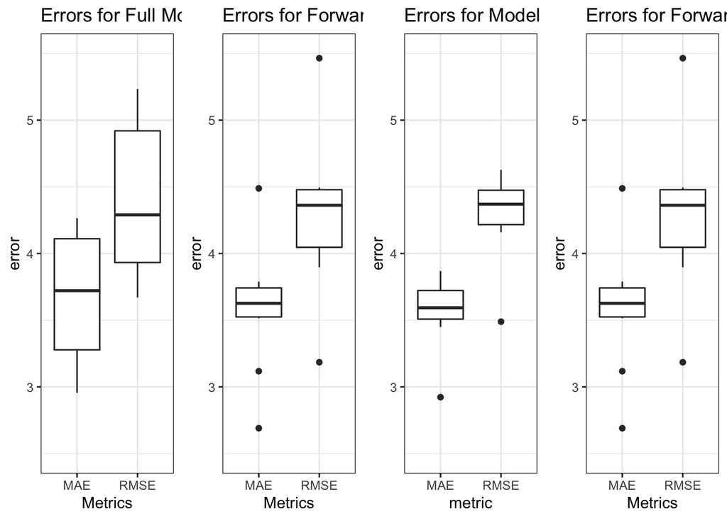

```r
b_all = cv_all$resample %>%
  as.data.frame() %>%
  dplyr::select(MAE, RMSE) %>%
  gather(key = "metric", value = "error") %>%
  ggplot() +
  aes(x = metric, y = error) +
  geom_boxplot() +
  labs(title = "Errors for Full Model",
       x="Metrics") +
  theme_bw() + ylim(2.5,5.5)

b_forward = cv_forward$resample %>%
  as.data.frame() %>%
  dplyr::select(MAE, RMSE) %>%
  gather(key = "metric", value = "error") %>%
  ggplot() +
  aes(x = metric, y = error) +
  geom_boxplot() +
  labs(title = "Errors for Forward Optimised Model",
       x = "Metrics") +
  theme_bw() + ylim(2.5,5.5)


b_backward = cv_backward$resample %>%
  as.data.frame() %>%
  dplyr::select(MAE, RMSE) %>%
  gather(key = "metric", value = "error") %>%
  ggplot() +
  aes(x = metric, y = error) +
  geom_boxplot() +
  labs(title = "Errors for Backward Optimised Model",
       x = "Metrics") +
  theme_bw() + ylim(2.5,5.5)

b_stable = cv_stable$resample %>%
  as.data.frame() %>%
  dplyr::select(MAE, RMSE) %>%
  gather(key = "metric", value = "error") %>%
  ggplot() +
  aes(x = metric, y = error) +
  geom_boxplot() +
  labs(title = "Errors for Model from stability plot") +
  theme_bw() + ylim(2.5,5.5)



gridExtra::grid.arrange(b_all, b_forward, b_stable, b_forward, ncol = 4)
```

### Appropriate Model Selection

#### Variable inclusion plot

```r
#full_model
#vis_full = vis(full_model, nbest = 10)
#bgn_full = bglmnet(full_model)

#plots dont show up in the knitted html
#plot(bgn_full, which = "vip", interactive = TRUE)
#plot(vis_full, which = "vip", interactive = TRUE)

#loss vs dimension plot - these plots don't work as expected .
#plot(vis_full, which = "lvk", interactive = TRUE)
# plot(vis_full, which = "boot", interactive = TRUE)


## More clustered plots (like in lectures)
#vis_full = vis(lm(Pct.BF ~. - Density - Waist, data=bodyfat))
#plot(vis_full, which = "lvk", highlight = "Abdomen", interactive=TRUE)

#plot(vis_full, which="boot", max.circle=0.25, highlight="Abdomen", interactive=TRUE)
```

### Assumption Checks

1. Linearity
2. Homoscedasticity
3. Normality

The following assumption checking, looks at the step.back.aic model. Looking at linearity assumption

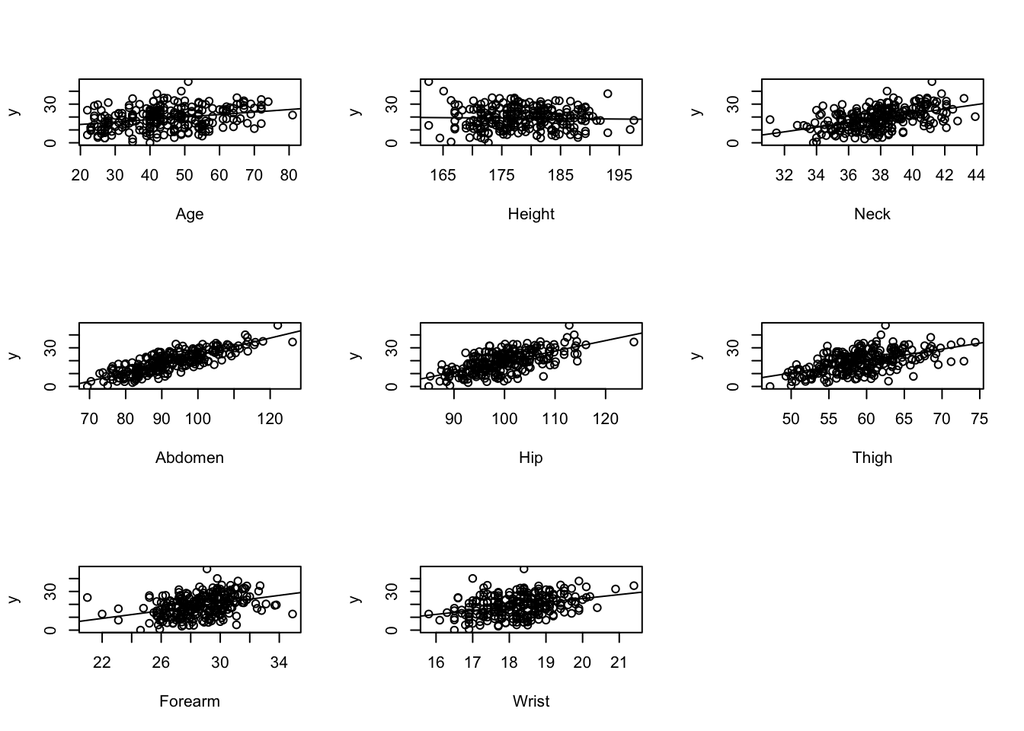

```r
par(mfrow = c(3, 3))
for (i in 1:length(model_vars)){
        x = bodyfat[model_vars][[model_vars[i]]]
        y = bodyfat$Pct.BF
        plot(x,y, xlab=model_vars[i])
        abline(lm(y~x))
}
```

There is some concern over the linearity assumption in our Age and Height predictors (Open up plot in separate window to observe better plotting).

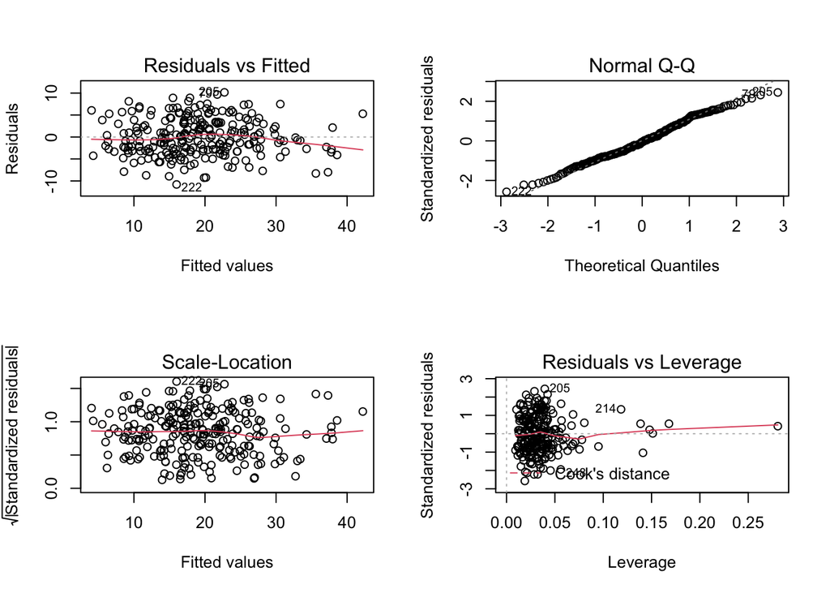

```r
par(mfrow=c(2,2))
plot(step.back.aic)
```

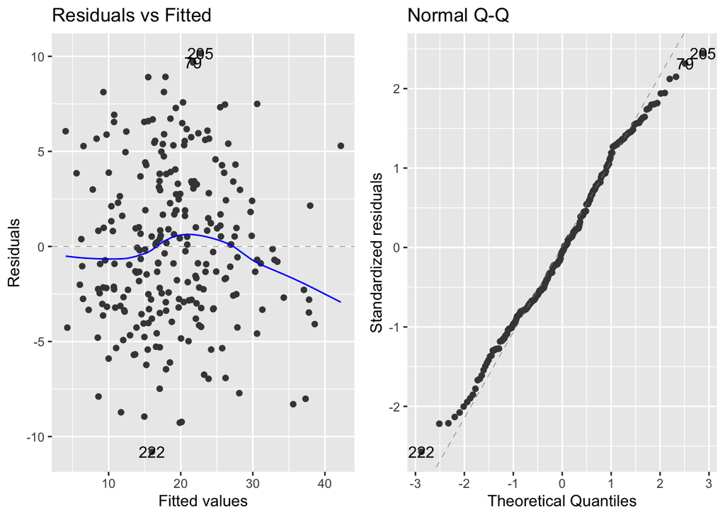

```r
autoplot(step.back.aic, which=c(1:2))
```

```r
step.back.aic$residuals
```

[output not shown]

[output cut: 29 more lines]

[output not shown]

QQ plot suggests that the normality assumption is satisfied. Relative flatness of red line in top left plot indicates homoscedasticity. There appears to be rather equal spread of residuals.